| title: “Qusage: Speeding up AggregateGeneSet in RcppArmadillo” |
| --- |
| author: “Timothy J. Triche, Jr, Anthony R. Colombo” |
| output: |
| pdf_document: |
| toc: true |
| number_sections: true |
| date: “28 March, 2016” |

# SpeedSage Intro

qusage is published software that is slow for large runs, SpeedSage corrects for speed and efficiency at large orders. there is Bottlenecking of Functions Qusage can improve the speed of its algorithm by minimizing the cost of computaiton.

# aggregateGeneSet Function

This test will perform the computations in the apply functions in c++. for makeComparisons and calcVIF, speedSage assumes the Welch’s approximation for variances between groups being unequal. Welch’s approximation is used for aggregateGeneSet function. Previously the qusage.single/makeComparison in Armadillo/speedSage has a 1.3-1.48X speed up, aggregateGeneSet is the second bottleneck that must be accelerated. the speed gains is calculated by the differences of the sub-routeins called by the parent-routines between respective methods. it is linear.

```r
library(inline)
library(microbenchmark)
library(Rcpp)
library(parallel)
library(speedSage)
library(qusage)
```

```r
library(ggplot2)
eset<-system.file("extdata","eset.RData",package="speedSage")
load(eset)
labels<-c(rep("t0",134),rep("t1",134))
contrast<-"t1-t0"
colnames(eset)<-c(rep("t0",134),rep("t1",134))
fileISG<-system.file("extdata","c2.cgp.v5.1.symbols.gmt",package="speedSage")
ISG.geneSet<-read.gmt(fileISG)
geneSets<-ISG.geneSet[grepl("DER_IFN_GAMMA_RESPONSE_UP",names(ISG.geneSet))]


#cpp functions
sourceCpp(file="/home/arcolombo/Documents/github_repos/SpeedSage/R/sigmaArm.cpp")
sourceCpp(file="/home/arcolombo/Documents/github_repos/SpeedSage/R/sigmaSingle.cpp")
sourceCpp(file="/home/arcolombo/Documents/github_repos/SpeedSage/R/bayesEstimation.cpp")
sourceCpp(file="/home/arcolombo/Documents/github_repos/SpeedSage/R/notbayesEstimation.cpp")
sourceCpp(file="/home/arcolombo/Documents/github_repos/SpeedSage/R/calcVIFarm.cpp")
sourceCpp(file="/home/arcolombo/Documents/github_repos/SpeedSage/R/calcVIFarmalt.cpp")
sourceCpp(file="/home/arcolombo/Documents/github_repos/SpeedSage/R/calcVIFarm_nosdalphaalt.cpp")
sourceCpp(file="/home/arcolombo/Documents/github_repos/SpeedSage/R/aggregategsSumSigma.cpp")
source(file="/home/arcolombo/Documents/github_repos/SpeedSage/R/qusageArm.R")


pairVector<-NULL
var.equal<-FALSE
filter.genes<-FALSE
n.points<-2^12

#setting up aggregateGeneSetArm call objects
results = makeComparisonArm(eset, labels, contrast, pairVector=pairVector,var.equal=var.equal)
```

```
## Found more than one class "QSarray" in cache; using the first, from namespace 'speedSage'
```

```r
nu = floor(min(results$dof,na.rm=T))
defaultAggregate = aggregateGeneSet(results, geneSets, silent=F, n.points=n.points)
geneResults<-results


 NumSDs<-abs(qt(10^-10,1:250))
  NumSDs[NumSDs>750] = 750
  Means = geneResults$mean
  SD = geneResults$SD
  DOF=geneResults$dof
  COLS = names(Means)

  if(is.vector(geneSets) & !is.list(geneSets)){
    n = deparse(substitute(geneSets))
    geneSets = list(geneSets)
    names(geneSets) = n
  }

 if(is.null(names(geneSets))){names(geneSets) = 1:length(geneSets)}

geneSets<- lapply(geneSets,function(x){
    if(is.numeric(x)){
      if(any(!(x %in% 1:length(COLS)))){stop("Numeric gene set indices out of bounds")}
      return(x)
    }
 which(COLS%in%x)
  })


myAg<-aggregategsSumSigma(results$SD, results$dof,geneSets)
```

# Microbenchmarking subset positon COLS in geneSet

I’ve tried to reduce the which command using Rcpp find but it was much slower

```r
#guts of the function, comparing the direct methods
mb<-microbenchmark(
sapply(names(geneSets),function(i){
      Indexes = geneSets[[i]]
      x<-sqrt(sum((SD^2*(DOF/(DOF-2)))[Indexes]))
      return(x)
  }),

 MinDof<-sapply(names(geneSets),function(i){
      Indexes = geneSets[[i]]
      if(length(Indexes)==0){return(NA)}
      return(floor(min(DOF[Indexes])))
      }),
 SumSigma_MinDof<-aggregategsSumSigma(geneResults$SD,geneResults$dof,geneSets)


, times=2500)


#mb shows microseconds speed up


#need to check accuracy, and need to show speed.
#need to check the aggregateGeneSet.R versus aggregateGeneSetArm.R  for 1 geneSet,  and 3 geneSets, compare accuracy and speed.  then wrap up.

source("/home/arcolombo/Documents/github_repos/SpeedSage/R/aggregateGeneSet.R")
source("/home/arcolombo/Documents/github_repos/SpeedSage/R/aggregateGeneSetArm.R")

#accuracy


defaultAggregate = aggregateGeneSet(results, geneSets, silent=F, n.points=n.points)
myAg<-aggregateGeneSetArm(results, geneSets, silent=F,n.points=n.points, armadillo=TRUE)
defAg<-aggregateGeneSetArm(results, geneSets, silent=F,n.points=n.points, armadillo=FALSE)

singleMb<-microbenchmark(
myAg<-aggregateGeneSetArm(results, geneSets, silent=F,n.points=n.points, armadillo=TRUE),
defaultAggregate = aggregateGeneSet(results, geneSets, silent=F, n.points=n.points),times=250)

#single gene set no speed pu
singleMb
```

```
## Unit: milliseconds
##                                                                                                    expr
##  myAg <- aggregateGeneSetArm(results, geneSets, silent = F, n.points = n.points,      armadillo = TRUE)
##                                                                                        defaultAggregate
##       min       lq     mean   median       uq      max neval cld
##  63.39874 66.82738 76.37854 69.35153 72.07884 133.9434   250   b
##  62.97385 66.71517 73.17879 68.92583 71.16445 145.7601   250  a
```

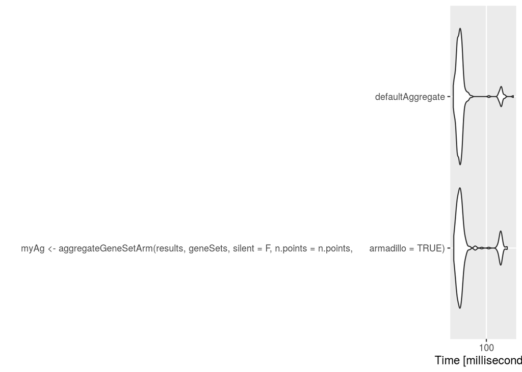

```r
library(ggplot2)
autoplot(singleMb)
```

```r
geneSets[2]<-geneSets[1]
geneSets[3]<-geneSets[1]
multiSets<-geneSets
multiMb<-microbenchmark(
myAg<-aggregateGeneSetArm(results, multiSets, silent=F,n.points=n.points, armadillo=TRUE),
defaultAggregate = aggregateGeneSet(results, multiSets, silent=F, n.points=n.points),times=250)

multiMb
```

```
## Unit: milliseconds
##                                                                                                     expr
##  myAg <- aggregateGeneSetArm(results, multiSets, silent = F, n.points = n.points,      armadillo = TRUE)
##                                                                                         defaultAggregate
##       min       lq     mean   median       uq      max neval cld
##  198.5365 204.4651 233.9611 210.3341 263.4129 322.3163   250   a
##  200.0688 206.1108 236.4384 215.2019 264.4701 322.1849   250   a
```

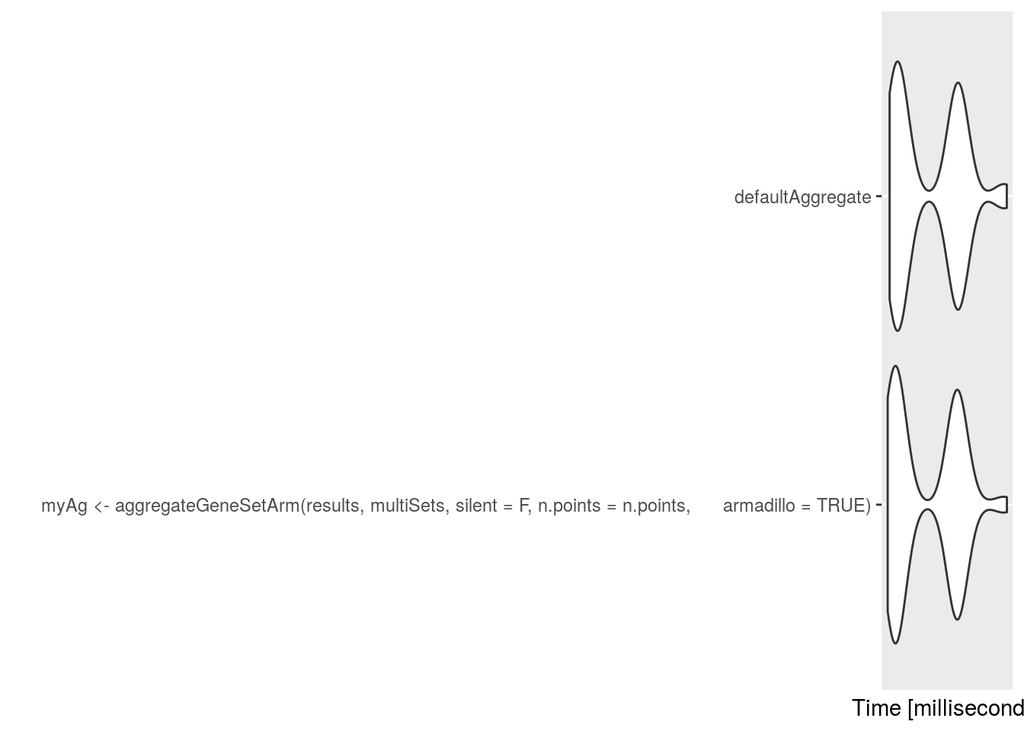

```r
#the gain is only in terms of microseconds, although additive, it is not noticeable.
autoplot(multiMb)
```

```r
#the grouping of the PDF formation is also bottlenecking
```